# Lab 10: Neural Networkds and Deep Learning

The purpose of this lab is to get experience with neural networks and deep learning.

**It is strongly recommended that you complete this lab on the VMs, but it can perhaps also be completed on any computer that has R (version >= 4.0) available. Your final R markdown document must be processed on the VMs to produce the HTML document for submission.**

# Data

We will continue to use the two Zip code datasets that we have used in the past few labs (source: https://hastie.su.domains/ElemStatLearn/data.html).

To perform the following tasks, make sure you have loaded the following libraries:

```r
library(keras)
```

This is the only library that is to be used in this lab for the study of neural networks.

# Introduction

1. In your own words, describe briefly the data and the data mining problems that are studied in this lab.

# An Image

2. Produce a 10x10 image that looks similar to the following, where each handwritten digit is randomly chosen from the subset with its corresponding numeral value in the training set. (You may reverse black and white in the image, if you like.)

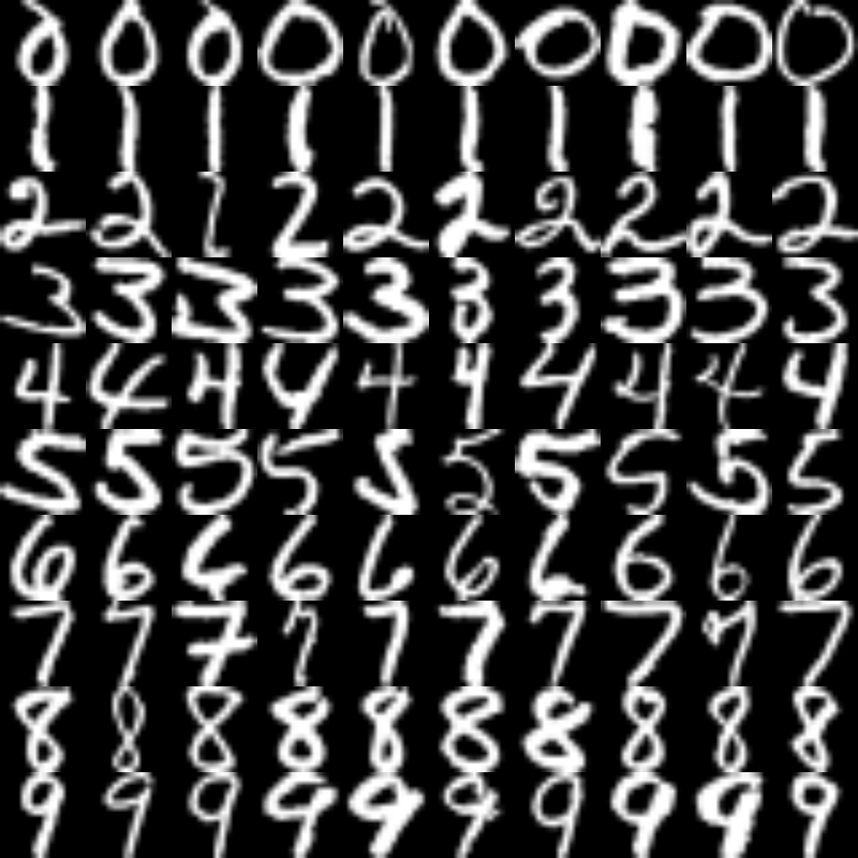

# Using Two Predictors

3. In Tasks 2-6 will continue our study of using two predictors, `p167` and `p105`, for predicting `digit=2` or `3`.

   Fit 4 neural networks by minimising (sufficiently) the cross-entropy objective function. Each network has one layer of hidden units, with the number of units being 1, 2, 3, 4, respectively.

   Compute their training and test errors (for the `train` and `test` sets).
4. For each of the 4 fitted neural networks obtained in Task 3, plot its decision boundary inside a scatter plot of the training data.
5. Fit a neural network with two hidden layers, with the numbers of units being (4,3), by minimising (sufficiently) the cross-entropy objective function.

   Compute its training and test errors.
6. Re-do Task 5, by setting a validation fraction of 0.3 (data needs to be shuffled first). Monitor the performance for a sufficiently long time. Find an optimal value for `epoch` and refit the neural network. (It is also possible to use `callbacks`, if you know how to use them.)

   Compute the training and test errors of the final neural network.

# Using All Predictors

7. Re-do Task 6, but with all 256 predictors used.
8. Consider using convolutional neural networks for predicting `digit=2` or `3`, with all 256 predictors used.

   Compute the training and test errors of a well-trained neural network.
9. Re-do Task 8, but for the 10-class classification problem (`digit=0,1,...,9`).

# Summary

10. Write a summary of the entire report.

# The Report

Your submission should consist of an R Markdown document, submitted via Canvas. You should write your document so that I can process it on my computer without any manual intervention. For example, do not include any calls to `setwd()` or `file.choose()`. You should write code that assumes that data ﬁles are in the current working directory or at a fixed location on the VMs. Also submit a processed version of your R Markdown document (an HTML document) in case I cannot process your document on my computer.

Your report should include:

- A brief description of the data.
- For each task, R code AND a brief text commentary.
- A summary of the entire report.

# Marking

Marks will be lost for:

- R Markdown ﬁle is missing.
- R Markdown ﬁle does not run.
- Processed ﬁle (HTML) is missing.
- Section of the report is missing.
- Unintelligible, or confusing, or irrelevant summary.
- Signiﬁcantly poor R (or other) code.
- Overly verbose code, output, or commentary.

This work is licensed under a [Creative Commons Attribution 4.0 International License](http://creativecommons.org/licenses/by/4.0/).